# OxFord COVID-19 Data Exploration

Estefania Avila, Meitong Hu, Egle Klekere, Alla Polishchuk, Jingjing Zhang

## Data Source & Summary

OXFORD COVID-19 GOVERNMENT RESPONSE TRACKER: aims to track and compare government responses to the coronavirus outbreak worldwide rigorously and consistently. We can analyze how specific government measures affect outcomes in terms of COVID cases and deaths. https://www.bsg.ox.ac.uk/research/research-projects/oxford-covid-19-government-response-tracker

#### 13 Measures Tracked by Oxford:

- S1_School closing
- S2_Workplace closing
- S3_Cancel public events
- S4_Close public transport
- S5_Public information campaigns
- S6_Restrictions on internal movement
- S7_International travel controls
- S8_Fiscal measures
- S9_Monetary measures
- S10_Emergency investment in health care
- S11_Investment in Vaccines
- S12_Testing framework
- S13_Contact tracing

OxCGRT collects publicly available information on 13 indicators of government response (S1-S13). Nine of the indicators (S1-S7, S12 and S13) take policies such as school closures, travel bans, etc. are recorded on an ordinal scale; the remainder (S8-S11) are financial indicators such as fiscal or monetary measures.

This endpoint provides JSON by with country stringency data, confirmed cases and deaths on a day by day basis as collected by our data collection team. The stringency_actual field is the daily calculated data. The stringency field is a convenience field for visualisations which holds previous day data (up to 7 days) if data in unavailable for a given day.

#### Other data in dataset:

- ConfirmedCases
- ConfirmedDeaths
- StringencyIndex

## Data Exploration

### Read File

Read file in. Noticed it has a lot of “Notes” columns used to supply source of change in variable. The “General” columns indicate whether measure is geographically targeted or general.

```r
# read the csv into a dataframe
data = read.csv("OxCGRT_Download_190420_130939_Full.csv")

# see columns in data
names(data)
```

```
##  [1] "CountryName"
##  [2] "CountryCode"
##  [3] "Date"
##  [4] "S1_School.closing"
##  [5] "S1_IsGeneral"
##  [6] "S1_Notes"
##  [7] "S2_Workplace.closing"
##  [8] "S2_IsGeneral"
##  [9] "S2_Notes"
## [10] "S3_Cancel.public.events"
## [11] "S3_IsGeneral"
## [12] "S3_Notes"
## [13] "S4_Close.public.transport"
## [14] "S4_IsGeneral"
## [15] "S4_Notes"
```

[output cut: 25 more lines]

#### Get Top Countries

```r
# number countries interested in
num_c = 30
# date evaluated
e_date = 20200419

# look at the rows with the evaluation date
data_eval = subset(data, data$Date == e_date)
# order data in descending order based on num cases and deaths
data_eval = data_eval[order(-data_eval$ConfirmedCases, -data_eval$ConfirmedDeaths),]
# take the levels of first num_c rows of the CountryName column
top = levels(factor(head(data_eval,num_c)$CountryName))

top
```

```
##  [1] "Austria"        "Belgium"        "Brazil"         "Canada"
##  [5] "Chile"          "China"          "Ecuador"        "France"
##  [9] "Germany"        "India"          "Iran"           "Ireland"
## [13] "Israel"         "Italy"          "Japan"          "Netherlands"
## [17] "Pakistan"       "Peru"           "Poland"         "Portugal"
## [21] "Romania"        "Russia"         "Saudi Arabia"   "South Korea"
## [25] "Spain"          "Sweden"         "Switzerland"    "Turkey"
## [29] "United Kingdom" "United States"
```

#### Filter data to only include Top Countries

```r
# take the subset of data related to top countries
df_top = subset(data, CountryName %in% top)
df_top = subset(df_top, df_top$Date <= e_date)

# drop unused levels from all factors
df_top[] = lapply(df_top, function(x) if(is.factor(x)) factor(x) else x)
df = df_top
```

#### Dealing with General vs Targetted

Data includes targeted and general measures. When the general column is 1 it means the measure was general (for the whole country), when the general column is 0 it means the measure was targetted to a specific geographical locaiton. We are only interested in looking at data generally applied to the whole country.

```r
# find columns with General in name
General = c(grep( "General" , names( df) ))

# multiple isGeneral column to measure column and only look at general data
for (column in General){
  df[,column-1] = df[,column] * df[,column-1]
}
```

#### Separate or remove excess columns

The Notes and General columns do not pertain to our prediction model. We will also only be using the Display Stringency Index as it is more complete.

```r
# find columns with Notes in name
Notes = c(grep( "Notes" , names( df) ))
# save notes and general as separate df's
df_notes = subset(df, select = Notes )
df_general = subset( df, select = General )
# remove notes and general columns from main df
df = subset( df, select = -c(Notes, General))

# remove duplicate stringency index and X column
df = subset(df, select = -c(StringencyIndex, X))

str(df)
```

```
## 'data.frame':    3300 obs. of  19 variables:
##  $ CountryName                            : Factor w/ 30 levels "Austria","Belgium",..: 1 1 1 1 1 1 1 1 1 1 ...
##  $ CountryCode                            : Factor w/ 30 levels "AUT","BEL","BRA",..: 1 1 1 1 1 1 1 1 1 1 ...
##  $ Date                                   : int  20200101 20200102 20200103 20200104 20200105 20200106 20200107 20200108 20200109 20200110 ...
##  $ S1_School.closing                      : int  NA NA NA NA NA NA NA NA NA NA ...
##  $ S2_Workplace.closing                   : int  NA NA NA NA NA NA NA NA NA NA ...
##  $ S3_Cancel.public.events                : int  NA NA NA NA NA NA NA NA NA NA ...
##  $ S4_Close.public.transport              : int  NA NA NA NA NA NA NA NA NA NA ...
##  $ S5_Public.information.campaigns        : int  NA NA NA NA NA NA NA NA NA NA ...
##  $ S6_Restrictions.on.internal.movement   : int  NA NA NA NA NA NA NA NA NA NA ...
##  $ S7_International.travel.controls       : int  0 0 0 0 0 0 0 0 0 0 ...
##  $ S8_Fiscal.measures                     : num  0 0 0 0 0 0 0 0 0 0 ...
##  $ S9_Monetary.measures                   : num  0 0 0 0 0 0 0 0 0 0 ...
##  $ S10_Emergency.investment.in.health.care: num  0 0 0 0 0 0 0 0 0 0 ...
##  $ S11_Investment.in.Vaccines             : num  0 0 0 0 0 0 0 0 0 0 ...
##  $ S12_Testing.framework                  : int  NA NA NA NA NA NA NA NA NA NA ...
##  $ S13_Contact.tracing                    : int  NA NA NA NA NA NA NA NA NA NA ...
##  $ ConfirmedCases                         : int  0 0 0 0 0 0 0 0 0 0 ...
##  $ ConfirmedDeaths                        : int  0 0 0 0 0 0 0 0 0 0 ...
##  $ StringencyIndexForDisplay              : num  0 0 0 0 0 0 0 0 0 0 ...
```

```r
summary(df)
```

```
##   CountryName    CountryCode        Date          S1_School.closing
##  Austria: 110   AUT    : 110   Min.   :20200101   Min.   :0.000
##  Belgium: 110   BEL    : 110   1st Qu.:20200128   1st Qu.:0.000
##  Brazil : 110   BRA    : 110   Median :20200224   Median :2.000
##  Canada : 110   CAN    : 110   Mean   :20200249   Mean   :1.113
##  Chile  : 110   CHE    : 110   3rd Qu.:20200323   3rd Qu.:2.000
##  China  : 110   CHL    : 110   Max.   :20200419   Max.   :2.000
##  (Other):2640   (Other):2640                      NA's   :1646
##  S2_Workplace.closing S3_Cancel.public.events S4_Close.public.transport
##  Min.   :0.0000       Min.   :0.000           Min.   :0.0000
##  1st Qu.:0.0000       1st Qu.:0.000           1st Qu.:0.0000
##  Median :0.0000       Median :1.000           Median :0.0000
##  Mean   :0.7861       Mean   :1.071           Mean   :0.5162
##  3rd Qu.:2.0000       3rd Qu.:2.000           3rd Qu.:1.0000
##  Max.   :2.0000       Max.   :2.000           Max.   :2.0000
##  NA's   :1771         NA's   :1634            NA's   :2372
##  S5_Public.information.campaigns S6_Restrictions.on.internal.movement
##  Min.   :0.0000                  Min.   :0.0000
##  1st Qu.:1.0000                  1st Qu.:0.0000
##  Median :1.0000                  Median :0.0000
##  Mean   :0.7675                  Mean   :0.8179
##  3rd Qu.:1.0000                  3rd Qu.:2.0000
##  Max.   :1.0000                  Max.   :2.0000
##  NA's   :1154                    NA's   :1620
##  S7_International.travel.controls S8_Fiscal.measures  S9_Monetary.measures
##  Min.   :0.000                    Min.   :0.000e+00   Min.   :-0.750
##  1st Qu.:0.000                    1st Qu.:0.000e+00   1st Qu.: 0.000
##  Median :0.000                    Median :0.000e+00   Median : 0.000
##  Mean   :1.228                    Mean   :2.015e+09   Mean   : 1.918
##  3rd Qu.:3.000                    3rd Qu.:0.000e+00   3rd Qu.: 2.000
##  Max.   :3.000                    Max.   :1.958e+12   Max.   :18.000
##  NA's   :114                      NA's   :141         NA's   :133
##  S10_Emergency.investment.in.health.care S11_Investment.in.Vaccines
##  Min.   :0.000e+00                       Min.   :        0
##  1st Qu.:0.000e+00                       1st Qu.:        0
##  Median :0.000e+00                       Median :        0
##  Mean   :1.326e+08                       Mean   :   731278
##  3rd Qu.:0.000e+00                       3rd Qu.:        0
##  Max.   :2.424e+11                       Max.   :826000000
##  NA's   :144                             NA's   :242
##  S12_Testing.framework S13_Contact.tracing ConfirmedCases   ConfirmedDeaths
##  Min.   :0.0000        Min.   :0.000       Min.   :     0   Min.   :    0.00
##  1st Qu.:0.0000        1st Qu.:0.000       1st Qu.:     0   1st Qu.:    0.00
##  Median :1.0000        Median :1.000       Median :    28   Median :    0.00
##  Mean   :0.8496        Mean   :0.739       Mean   : 12760   Mean   :  747.31
##  3rd Qu.:1.0000        3rd Qu.:1.000       3rd Qu.:  5093   3rd Qu.:   86.75
##  Max.   :3.0000        Max.   :2.000       Max.   :735086   Max.   :38910.00
##  NA's   :208           NA's   :219         NA's   :422      NA's   :422
##  StringencyIndexForDisplay
##  Min.   :  0.00
##  1st Qu.:  0.00
##  Median : 14.29
##  Mean   : 34.47
##  3rd Qu.: 71.43
##  Max.   :100.00
##  NA's   :14
```

#### Deal with NAs and NULLs

Since values are dependent per country, there was little general NA cleaning we could do. More cleaning was done per country.

```r
# make all January 1st values zero if NA
df[df$Date == 20200101 & is.na(df)] <- 0
```

#### Convert Date Column to Date Format

Date column is in integer format, we converted it to date format to be able to find differences between dates.

```r
# turn date column into date format
df$Date <- as.Date(as.character(df$Date),"%Y%m%d")
```

### Flatten Data

#### Separate Columns

Some measures need to be summed to that point (measures). Others can just be taken at the face value rather than cumulative (info).

```r
info = c("Date", "CountryName", "CountryCode", "ConfirmedCases", "ConfirmedDeaths") #, "StringencyIndexForDisplay")
measures = names(df)[!(names(df) %in% info)]
#measures
```

#### Create Empty Dataframe to input new information

```r
# create empty data frame
df_flat <- data.frame(Date=as.Date(character()),
                      Day = integer(),
                     CountryName=character(),
                     CountryCode=character(),
                     S1_School.closing = integer(),
                     S2_Workplace.closing = integer(),
                     S3_Cancel.public.events = integer(),
                     S4_Close.public.transport = integer(),
                     S5_Public.information.campaigns = integer(),
                     S6_Restrictions.on.internal.movement = integer(),
                     S7_International.travel.controls = integer(),
                     S8_Fiscal.measures = double(),
                     S9_Monetary.measures = double(),
                     S10_Emergency.investment.in.health.care = double(),
                     S11_Investment.in.Vaccines = double(),
                     S12_Testing.framework = integer(),
                     S13_Contact.tracing = integer(),
                     StringencyIndexForDisplay = double(),
                     ConfirmedCases = integer(),
                     ConfirmedDeaths = integer(),
                     GrowthRate = integer(),

                     ConfirmedCasesFut = integer(),
                     ConfirmedDeathsFut = integer(),
                     GrowthRateFut = integer(),

                     stringsAsFactors=FALSE)

str(df_flat)
```

```
## 'data.frame':    0 obs. of  24 variables:
##  $ Date                                   : 'Date' num(0)
##  $ Day                                    : int
##  $ CountryName                            : chr
##  $ CountryCode                            : chr
##  $ S1_School.closing                      : int
##  $ S2_Workplace.closing                   : int
##  $ S3_Cancel.public.events                : int
##  $ S4_Close.public.transport              : int
##  $ S5_Public.information.campaigns        : int
##  $ S6_Restrictions.on.internal.movement   : int
##  $ S7_International.travel.controls       : int
##  $ S8_Fiscal.measures                     : num
##  $ S9_Monetary.measures                   : num
##  $ S10_Emergency.investment.in.health.care: num
##  $ S11_Investment.in.Vaccines             : num
##  $ S12_Testing.framework                  : int
##  $ S13_Contact.tracing                    : int
##  $ StringencyIndexForDisplay              : num
##  $ ConfirmedCases                         : int
##  $ ConfirmedDeaths                        : int
##  $ GrowthRate                             : int
##  $ ConfirmedCasesFut                      : int
##  $ ConfirmedDeathsFut                     : int
##  $ GrowthRateFut                          : int
```

#### Flatten Data

```r
# day zero limit
limit = 100

# interval between dates captured
interval = 3

# num of intervals in future
fut = 4


# library needed to back fill NA values
library(zoo)
# for each country in the top list
for (country in top) {
  # subset of data only for that country
  df_country = subset(df, CountryName == country)
  # get the country code for that country
  cc = levels(factor(df_country$CountryCode))

  # fill NA values with last non-NA value for that country
  df_country$ConfirmedCases = na.locf(with(df_country, ifelse(df_country$ConfirmedCases == 'NA', NA_real_, df_country$ConfirmedCases)), fromLast = FALSE)
  df_country$ConfirmedDeaths = na.locf(with(df_country, ifelse(df_country$ConfirmedDeaths == 'NA', NA_real_, df_country$ConfirmedDeaths)), fromLast = FALSE)
  for (meas in measures){
    df_country[,meas] = na.locf(with(df_country, ifelse(df_country[,meas] == 'NA', NA_real_, df_country[,meas])), fromLast = FALSE)
  }

  # find row of zero-th day (when cases first >= limit)
  x = Position(function(x) x > limit, df_country$ConfirmedCases)

  # remove any data prior to zero-th day
  df_country_reset = tail(df_country, -x)

  # find dates to extract data from based on interval chosen
  dates = sort(df_country_reset$Date)
  dates = dates[seq(1, length(dates), interval)]
  dates_ = head(dates,-fut)

  # for every date of interest
  for (d in seq_along(dates_)){

    # subset of data only prior to date of interest
    df_dateFut = subset(df_country_reset, Date <= dates[d+fut])
    df_date = subset(df_country_reset, Date <= dates[d])

    # cumulate the measures
    cols = colSums(df_date[measures], na.rm = TRUE)


    # calculate growth rate
    if (d==1){
      g_rate = 0
    }
    else{
      g_rate = as.integer(df_date$ConfirmedCases[df_date$Date == dates[d]] - df_date$ConfirmedCases[df_date$Date == dates[d-1]])
    }

    if (d ==1){
      g_rate = 0
    }
    else{
      g_rate = as.integer(df_date$ConfirmedCases[df_date$Date == dates[d]]-df_date$ConfirmedCases[df_date$Date == dates[d-1]])
    }
    g_rateFut = as.integer(df_dateFut$ConfirmedCases[df_dateFut$Date == dates[d+fut]]-df_dateFut$ConfirmedCases[df_dateFut$Date == dates[d+fut-1]])

    # add data for specified date and country to dataframe
    df_flat <- rbind(df_flat, data.frame(Date = dates[d],
                    Day = as.integer(dates[d]-dates[1]),
                     CountryName = country,
                     CountryCode = cc,
                     S1_School.closing = as.integer(cols['S1_School.closing']),
                     S2_Workplace.closing = as.integer(cols['S2_Workplace.closing']),
                     S3_Cancel.public.events = as.integer(cols['S3_Cancel.public.events']),
                     S4_Close.public.transport = as.integer(cols['S4_Close.public.transport']),
                     S5_Public.information.campaigns = as.integer(cols['S5_Public.information.campaigns']),
                     S6_Restrictions.on.internal.movement = as.integer(cols['S6_Restrictions.on.internal.movement']),
                     S7_International.travel.controls = as.integer(cols['S7_International.travel.controls']),
                     S8_Fiscal.measures = cols['S8_Fiscal.measures'],
                     S9_Monetary.measures = cols['S9_Monetary.measures'],
                     S10_Emergency.investment.in.health.care = cols['S10_Emergency.investment.in.health.care'],
                     S11_Investment.in.Vaccines = cols['S11_Investment.in.Vaccines'],
                     S12_Testing.framework = as.integer(cols['S12_Testing.framework']),
                     S13_Contact.tracing = as.integer(cols['S13_Contact.tracing']),
                     StringencyIndexForDisplay = cols['StringencyIndexForDisplay'],
                     ConfirmedCases = as.integer(df_date$ConfirmedCases[df_date$Date == dates[d]]),
                     ConfirmedDeaths = as.integer(df_date$ConfirmedDeaths[df_date$Date == dates[d]]),
                    GrowthRate = g_rate,
                    ConfirmedCasesFut = as.integer(df_dateFut$ConfirmedCases[df_dateFut$Date == dates[d+fut]]),
                    ConfirmedDeathsFut = as.integer(df_dateFut$ConfirmedDeaths[df_dateFut$Date == dates[d+fut]]),
                    GrowthRateFut = g_rateFut))
  }
}

str(df_flat)
```

```
## 'data.frame':    315 obs. of  24 variables:
##  $ Date                                   : Date, format: "2020-03-10" "2020-03-13" ...
##  $ Day                                    : int  0 3 6 9 12 15 18 21 24 27 ...
##  $ CountryName                            : Factor w/ 30 levels "Austria","Belgium",..: 1 1 1 1 1 1 1 1 1 1 ...
##  $ CountryCode                            : Factor w/ 30 levels "AUT","BEL","BRA",..: 1 1 1 1 1 1 1 1 1 1 ...
##  $ S1_School.closing                      : int  0 0 2 8 14 20 26 32 38 44 ...
##  $ S2_Workplace.closing                   : int  0 2 6 12 18 24 30 36 42 48 ...
##  $ S3_Cancel.public.events                : int  0 6 12 18 24 30 36 42 48 54 ...
##  $ S4_Close.public.transport              : int  0 1 4 7 10 13 16 19 22 25 ...
##  $ S5_Public.information.campaigns        : int  1 4 7 10 13 16 19 22 25 28 ...
##  $ S6_Restrictions.on.internal.movement   : int  0 0 2 8 14 20 26 32 38 44 ...
##  $ S7_International.travel.controls       : int  3 12 21 30 39 48 57 66 75 84 ...
##  $ S8_Fiscal.measures                     : num  0.00 0.00 0.00 4.12e+10 4.12e+10 ...
##  $ S9_Monetary.measures                   : num  0 0 0 0 0 0 0 0 0 0 ...
##  $ S10_Emergency.investment.in.health.care: num  0 0 0 0 0 0 0 0 0 0 ...
##  $ S11_Investment.in.Vaccines             : num  0 0 0 0 0 0 0 0 0 0 ...
##  $ S12_Testing.framework                  : int  0 0 0 0 0 6 12 18 24 30 ...
##  $ S13_Contact.tracing                    : int  0 0 0 0 0 0 0 4 10 16 ...
##  $ StringencyIndexForDisplay              : num  28.6 195.2 433.3 719.1 1004.8 ...
##  $ ConfirmedCases                         : int  131 361 860 1646 3024 5282 7697 9618 11129 11983 ...
##  $ ConfirmedDeaths                        : int  0 1 1 4 8 30 68 108 158 204 ...
##  $ GrowthRate                             : num  0 230 499 786 1378 ...
##  $ ConfirmedCasesFut                      : int  3024 5282 7697 9618 11129 11983 12969 13807 14234 14603 ...
##  $ ConfirmedDeathsFut                     : int  8 30 68 108 158 204 273 337 384 431 ...
##  $ GrowthRateFut                          : int  1378 2258 2415 1921 1511 854 986 838 427 369 ...
```

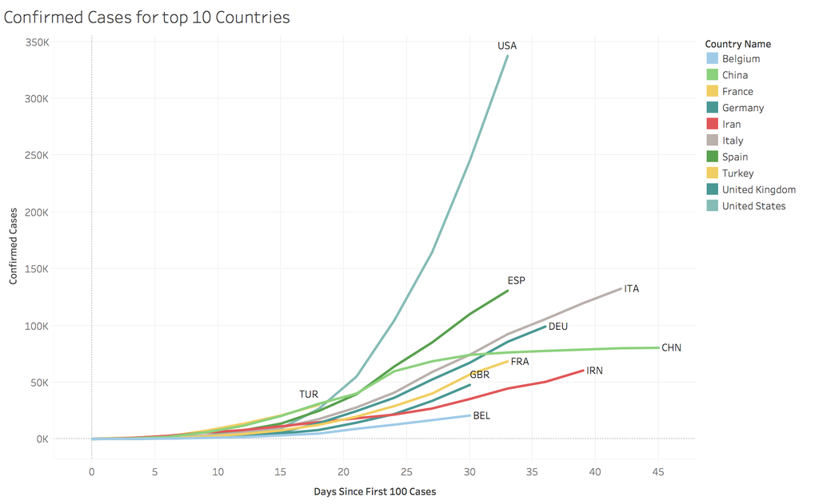

This figure shows an example of how the data was flattened. This case is for number of cases since day zero for each country.

### Linear Regression

#### Death Rate

```r
#Replace some values to unify the units.
df_flat$S11_Investment.in.Vaccines[df_flat$S11_Investment.in.Vaccines>1000]<-with(df_flat,S11_Investment.in.Vaccines[df_flat$S11_Investment.in.Vaccines>1000]*0.000001)
df_flat$S11_Investment.in.Vaccines<-round(df_flat$S11_Investment.in.Vaccines,1)

df_flat$S10_Emergency.investment.in.health.care[df_flat$S10_Emergency.investment.in.health.care>100000]<-with(df_flat,S10_Emergency.investment.in.health.care[df_flat$S10_Emergency.investment.in.health.care>100000]*0.000001)
df_flat$S10_Emergency.investment.in.health.care<-round(df_flat$S10_Emergency.investment.in.health.care,1)


# Creating a column named 'Death Rate' as the dependent variable.
df_flat$DeathRate<-round(df_flat$ConfirmedDeaths/df_flat$ConfirmedCases,3)
library(lmtest)
library(car)
# Run Linear Regression model.
df_flat_model<-lm(DeathRate ~ S1_School.closing+S2_Workplace.closing+S3_Cancel.public.events+S4_Close.public.transport+S5_Public.information.campaigns+S6_Restrictions.on.internal.movement+S7_International.travel.controls+S9_Monetary.measures+S10_Emergency.investment.in.health.care+S11_Investment.in.Vaccines+S12_Testing.framework+S13_Contact.tracing+S6_Restrictions.on.internal.movement*S7_International.travel.controls*S4_Close.public.transport+S1_School.closing*S2_Workplace.closing+S3_Cancel.public.events*S4_Close.public.transport,  data=df_flat)
summary(df_flat_model)
```

```
##
## Call:
## lm(formula = DeathRate ~ S1_School.closing + S2_Workplace.closing +
##     S3_Cancel.public.events + S4_Close.public.transport + S5_Public.information.campaigns +
##     S6_Restrictions.on.internal.movement + S7_International.travel.controls +
##     S9_Monetary.measures + S10_Emergency.investment.in.health.care +
##     S11_Investment.in.Vaccines + S12_Testing.framework + S13_Contact.tracing +
##     S6_Restrictions.on.internal.movement * S7_International.travel.controls *
##         S4_Close.public.transport + S1_School.closing * S2_Workplace.closing +
##     S3_Cancel.public.events * S4_Close.public.transport, data = df_flat)
##
## Residuals:
##       Min        1Q    Median        3Q       Max
## -0.054769 -0.010812 -0.001711  0.006892  0.093395
##
## Coefficients:
##                                                                                                   Estimate
## (Intercept)                                                                                      1.197e-02
## S1_School.closing                                                                               -5.671e-04
## S2_Workplace.closing                                                                            -8.496e-04
## S3_Cancel.public.events                                                                          1.651e-04
## S4_Close.public.transport                                                                        9.956e-04
## S5_Public.information.campaigns                                                                  1.135e-03
## S6_Restrictions.on.internal.movement                                                             1.219e-03
## S7_International.travel.controls                                                                -2.115e-04
## S9_Monetary.measures                                                                            -4.629e-05
## S10_Emergency.investment.in.health.care                                                         -1.740e-08
## S11_Investment.in.Vaccines                                                                       1.052e-05
## S12_Testing.framework                                                                            2.185e-05
## S13_Contact.tracing                                                                              1.323e-05
## S6_Restrictions.on.internal.movement:S7_International.travel.controls                           -2.556e-06
## S4_Close.public.transport:S6_Restrictions.on.internal.movement                                   3.301e-06
## S4_Close.public.transport:S7_International.travel.controls                                      -1.753e-05
## S1_School.closing:S2_Workplace.closing                                                           2.390e-05
## S3_Cancel.public.events:S4_Close.public.transport                                               -5.473e-05
## S4_Close.public.transport:S6_Restrictions.on.internal.movement:S7_International.travel.controls  7.839e-07
##                                                                                                 Std. Error
## (Intercept)                                                                                      2.008e-03
## S1_School.closing                                                                                1.443e-04
## S2_Workplace.closing                                                                             2.284e-04
```

[output cut: 67 more lines]

```
## S11_Investment.in.Vaccines
## S12_Testing.framework
## S13_Contact.tracing
## S6_Restrictions.on.internal.movement:S7_International.travel.controls
## S4_Close.public.transport:S6_Restrictions.on.internal.movement
## S4_Close.public.transport:S7_International.travel.controls
## S1_School.closing:S2_Workplace.closing                                                          ***
## S3_Cancel.public.events:S4_Close.public.transport                                               **
## S4_Close.public.transport:S6_Restrictions.on.internal.movement:S7_International.travel.controls *
## ---
## Signif. codes:  0 '***' 0.001 '**' 0.01 '*' 0.05 '.' 0.1 ' ' 1
##
## Residual standard error: 0.01725 on 296 degrees of freedom
## Multiple R-squared:  0.5757, Adjusted R-squared:  0.5499
## F-statistic: 22.31 on 18 and 296 DF,  p-value: < 2.2e-16
```

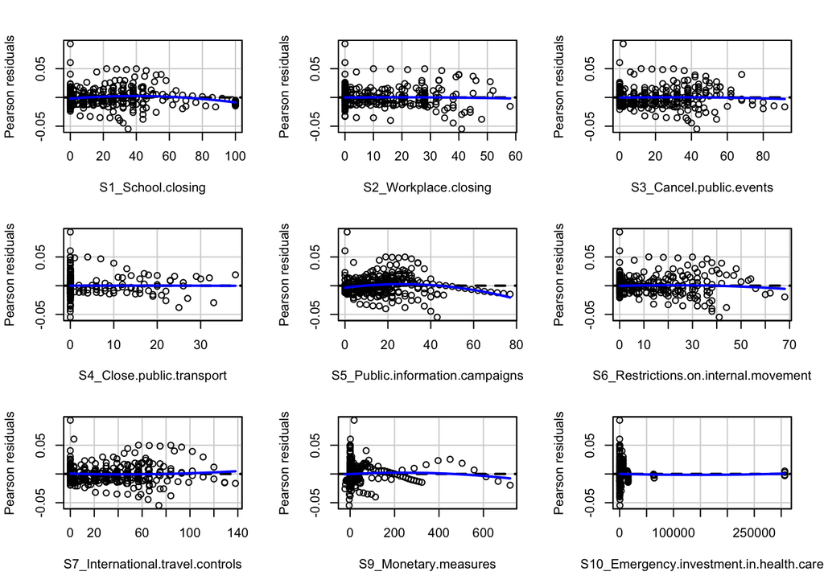

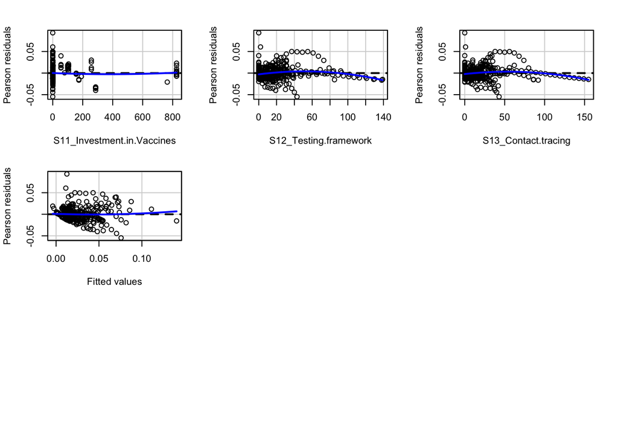

```
##                                         Test stat Pr(>|Test stat|)
## S1_School.closing                         -4.6882        4.218e-06 ***
## S2_Workplace.closing                      -0.4886        0.6254957
## S3_Cancel.public.events                   -0.5541        0.5799044
## S4_Close.public.transport                 -0.0404        0.9677690
## S5_Public.information.campaigns           -5.0481        7.823e-07 ***
## S6_Restrictions.on.internal.movement      -1.1232        0.2622506
## S7_International.travel.controls           1.4390        0.1512213
## S9_Monetary.measures                      -1.2762        0.2028904
## S10_Emergency.investment.in.health.care    0.2770        0.7819968
## S11_Investment.in.Vaccines                 0.7674        0.4434591
## S12_Testing.framework                     -3.6368        0.0003256 ***
## S13_Contact.tracing                       -3.6311        0.0003327 ***
## Tukey test                                 1.0150        0.3101076
## ---
## Signif. codes:  0 '***' 0.001 '**' 0.01 '*' 0.05 '.' 0.1 ' ' 1
```

```r
residualPlots(df_flat_model)
```

#### Growth Rate

A linear regression on growth rate vs all of the factors:

```r
# Run Linear Regression model.
g_rate_mod1<-lm(GrowthRate ~ S1_School.closing+S2_Workplace.closing+S3_Cancel.public.events+S4_Close.public.transport+S5_Public.information.campaigns+S6_Restrictions.on.internal.movement+S7_International.travel.controls+S8_Fiscal.measures+S9_Monetary.measures+S10_Emergency.investment.in.health.care+S11_Investment.in.Vaccines+S12_Testing.framework+S13_Contact.tracing,  data=df_flat)
summary(g_rate_mod1)
```

```
##
## Call:
## lm(formula = GrowthRate ~ S1_School.closing + S2_Workplace.closing +
##     S3_Cancel.public.events + S4_Close.public.transport + S5_Public.information.campaigns +
##     S6_Restrictions.on.internal.movement + S7_International.travel.controls +
##     S8_Fiscal.measures + S9_Monetary.measures + S10_Emergency.investment.in.health.care +
##     S11_Investment.in.Vaccines + S12_Testing.framework + S13_Contact.tracing,
##     data = df_flat)
##
## Residuals:
##      Min       1Q   Median       3Q      Max
## -21162.5  -1328.2   -510.5   1217.0  21555.7
##
## Coefficients:
##                                           Estimate Std. Error t value Pr(>|t|)
## (Intercept)                              6.649e+02  3.949e+02   1.684   0.0933
## S1_School.closing                       -2.614e+01  2.818e+01  -0.928   0.3544
## S2_Workplace.closing                    -1.316e+02  3.116e+01  -4.223 3.20e-05
## S3_Cancel.public.events                 -4.040e-01  2.253e+01  -0.018   0.9857
## S4_Close.public.transport               -3.785e+01  3.690e+01  -1.026   0.3058
## S5_Public.information.campaigns         -4.007e+01  5.308e+01  -0.755   0.4509
## S6_Restrictions.on.internal.movement     2.677e+02  3.537e+01   7.568 4.64e-13
## S7_International.travel.controls         4.759e+01  1.840e+01   2.586   0.0102
## S8_Fiscal.measures                       1.352e-08  2.114e-09   6.395 6.10e-10
## S9_Monetary.measures                    -1.172e+01  4.521e+00  -2.592   0.0100
## S10_Emergency.investment.in.health.care  1.270e-01  1.706e-02   7.440 1.06e-12
## S11_Investment.in.Vaccines               1.093e-01  1.839e+00   0.059   0.9527
## S12_Testing.framework                   -3.542e+01  2.636e+01  -1.344   0.1800
## S13_Contact.tracing                     -2.199e+00  2.062e+01  -0.107   0.9151
##
## (Intercept)                             .
## S1_School.closing
## S2_Workplace.closing                    ***
## S3_Cancel.public.events
## S4_Close.public.transport
## S5_Public.information.campaigns
## S6_Restrictions.on.internal.movement    ***
## S7_International.travel.controls        *
## S8_Fiscal.measures                      ***
## S9_Monetary.measures                    *
## S10_Emergency.investment.in.health.care ***
## S11_Investment.in.Vaccines
## S12_Testing.framework
## S13_Contact.tracing
## ---
## Signif. codes:  0 '***' 0.001 '**' 0.01 '*' 0.05 '.' 0.1 ' ' 1
##
## Residual standard error: 3876 on 301 degrees of freedom
## Multiple R-squared:  0.8293, Adjusted R-squared:  0.8219
## F-statistic: 112.5 on 13 and 301 DF,  p-value: < 2.2e-16
```

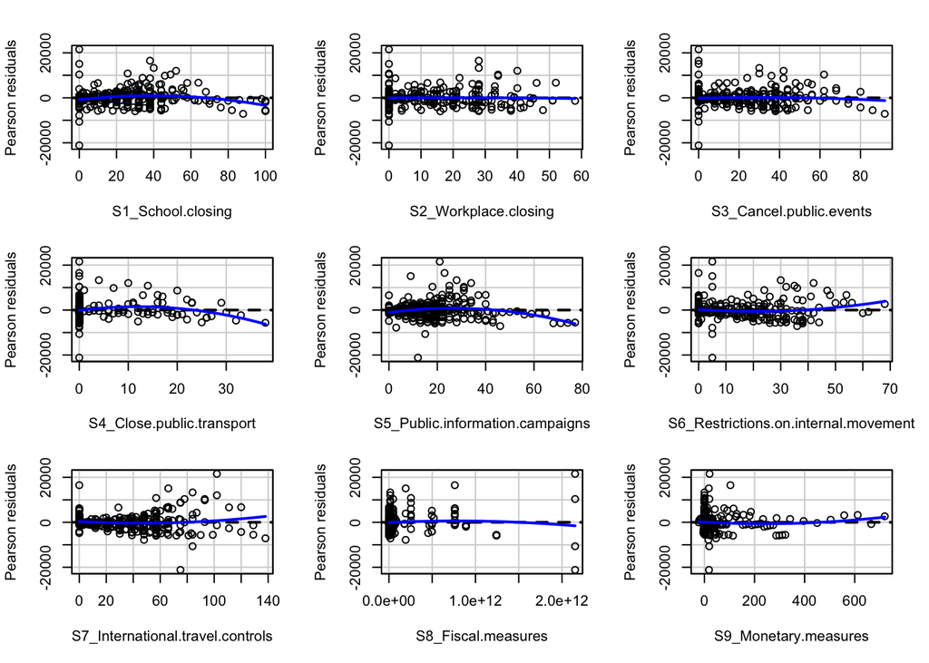

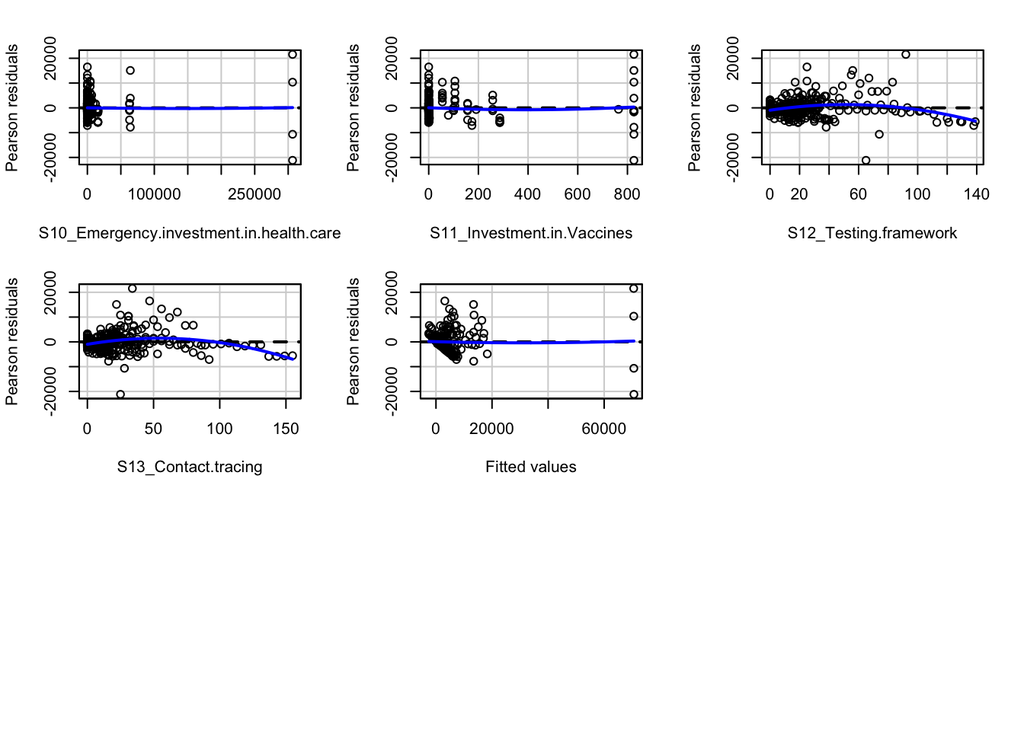

```
##                                         Test stat Pr(>|Test stat|)
## S1_School.closing                         -7.2959        2.666e-12 ***
## S2_Workplace.closing                      -0.2281         0.819721
## S3_Cancel.public.events                   -0.9717         0.331961
## S4_Close.public.transport                 -3.2683         0.001208 **
## S5_Public.information.campaigns           -6.3070        1.017e-09 ***
## S6_Restrictions.on.internal.movement       2.6505         0.008463 **
## S7_International.travel.controls           2.3526         0.019290 *
## S8_Fiscal.measures                        -2.5314         0.011872 *
## S9_Monetary.measures                       1.6185         0.106608
## S10_Emergency.investment.in.health.care    0.2093         0.834389
## S11_Investment.in.Vaccines                 1.0302         0.303741
## S12_Testing.framework                     -5.2327        3.143e-07 ***
## S13_Contact.tracing                       -7.1708        5.842e-12 ***
## Tukey test                                 0.7521         0.451994
## ---
## Signif. codes:  0 '***' 0.001 '**' 0.01 '*' 0.05 '.' 0.1 ' ' 1
```

```r
residualPlots(g_rate_mod1)
```

The above model indicates that Restriction on internal movement, International travel controls, Fiscal measures, and Emergency investment in health care all have a positive correlation to growth rate. Meanwhile Workplace closing, and Monetary measures have a negative correlation with growth rate. All other individual factors do not have a statistically significant correlation with growth rate.

A linear regression on growth rate vs all of the factors and some interactions:

```r
# Run Linear Regression model with interactions

g_rate_mod2<-lm(GrowthRate ~ S1_School.closing+S2_Workplace.closing+S3_Cancel.public.events+S4_Close.public.transport+S5_Public.information.campaigns+S6_Restrictions.on.internal.movement+S7_International.travel.controls+S8_Fiscal.measures+S9_Monetary.measures+S10_Emergency.investment.in.health.care+S11_Investment.in.Vaccines+S12_Testing.framework+S13_Contact.tracing+S6_Restrictions.on.internal.movement*S7_International.travel.controls*S4_Close.public.transport+S1_School.closing*S2_Workplace.closing+S3_Cancel.public.events*S4_Close.public.transport,  data=df_flat)
summary(g_rate_mod2)
```

```
##
## Call:
## lm(formula = GrowthRate ~ S1_School.closing + S2_Workplace.closing +
##     S3_Cancel.public.events + S4_Close.public.transport + S5_Public.information.campaigns +
##     S6_Restrictions.on.internal.movement + S7_International.travel.controls +
##     S8_Fiscal.measures + S9_Monetary.measures + S10_Emergency.investment.in.health.care +
##     S11_Investment.in.Vaccines + S12_Testing.framework + S13_Contact.tracing +
##     S6_Restrictions.on.internal.movement * S7_International.travel.controls *
##         S4_Close.public.transport + S1_School.closing * S2_Workplace.closing +
##     S3_Cancel.public.events * S4_Close.public.transport, data = df_flat)
##
## Residuals:
##      Min       1Q   Median       3Q      Max
## -21365.3  -1407.4   -428.8    912.0  21433.3
##
## Coefficients:
##                                                                                                   Estimate
## (Intercept)                                                                                      5.073e+02
## S1_School.closing                                                                               -2.030e+01
## S2_Workplace.closing                                                                            -6.423e+01
## S3_Cancel.public.events                                                                          2.522e+01
## S4_Close.public.transport                                                                        3.606e+02
## S5_Public.information.campaigns                                                                 -2.410e+01
## S6_Restrictions.on.internal.movement                                                             1.603e+02
## S7_International.travel.controls                                                                 3.951e+01
## S8_Fiscal.measures                                                                               1.168e-08
## S9_Monetary.measures                                                                            -5.826e+00
## S10_Emergency.investment.in.health.care                                                          1.423e-01
## S11_Investment.in.Vaccines                                                                       7.323e-01
## S12_Testing.framework                                                                           -3.583e+01
## S13_Contact.tracing                                                                             -7.994e+00
## S6_Restrictions.on.internal.movement:S7_International.travel.controls                            3.247e-01
## S4_Close.public.transport:S6_Restrictions.on.internal.movement                                   1.642e+01
## S4_Close.public.transport:S7_International.travel.controls                                      -8.894e+00
## S1_School.closing:S2_Workplace.closing                                                          -9.100e-01
## S3_Cancel.public.events:S4_Close.public.transport                                               -1.589e+01
## S4_Close.public.transport:S6_Restrictions.on.internal.movement:S7_International.travel.controls  1.477e-01
##                                                                                                 Std. Error
## (Intercept)                                                                                      4.391e+02
## S1_School.closing                                                                                3.193e+01
```

[output cut: 72 more lines]

```
## S11_Investment.in.Vaccines
## S12_Testing.framework
## S13_Contact.tracing
## S6_Restrictions.on.internal.movement:S7_International.travel.controls
## S4_Close.public.transport:S6_Restrictions.on.internal.movement                                  *
## S4_Close.public.transport:S7_International.travel.controls                                      **
## S1_School.closing:S2_Workplace.closing
## S3_Cancel.public.events:S4_Close.public.transport                                               ***
## S4_Close.public.transport:S6_Restrictions.on.internal.movement:S7_International.travel.controls .
## ---
## Signif. codes:  0 '***' 0.001 '**' 0.01 '*' 0.05 '.' 0.1 ' ' 1
##
## Residual standard error: 3757 on 295 degrees of freedom
## Multiple R-squared:  0.8428, Adjusted R-squared:  0.8326
## F-statistic: 83.22 on 19 and 295 DF,  p-value: < 2.2e-16
```

[figure not shown]